# MLE&MAP4

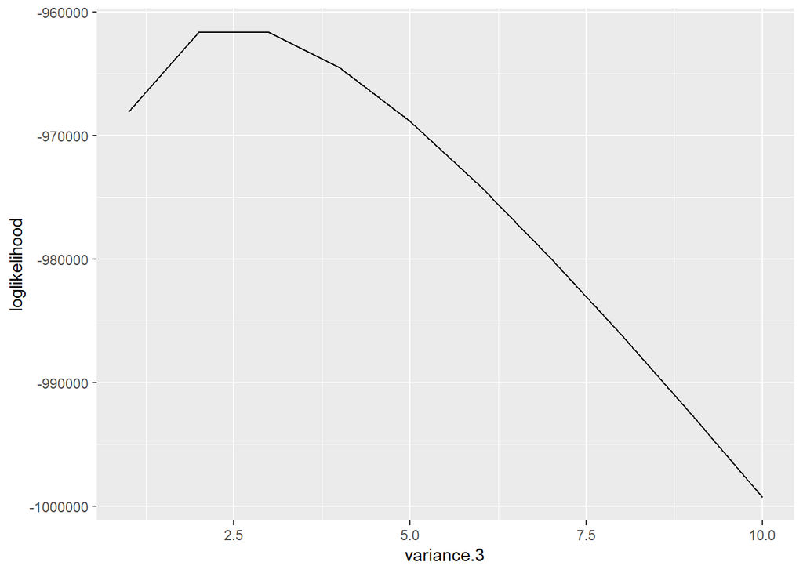

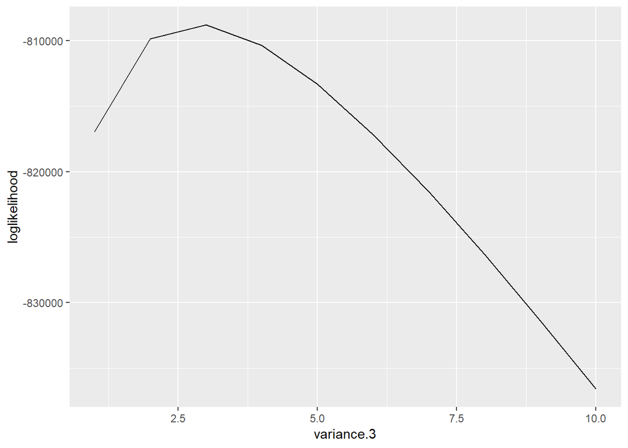

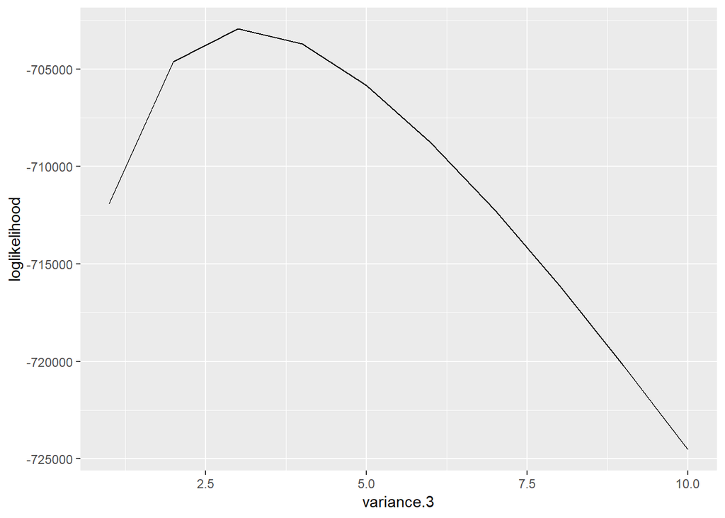

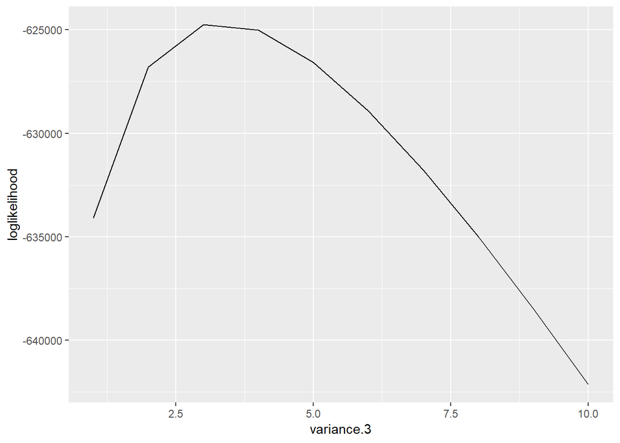

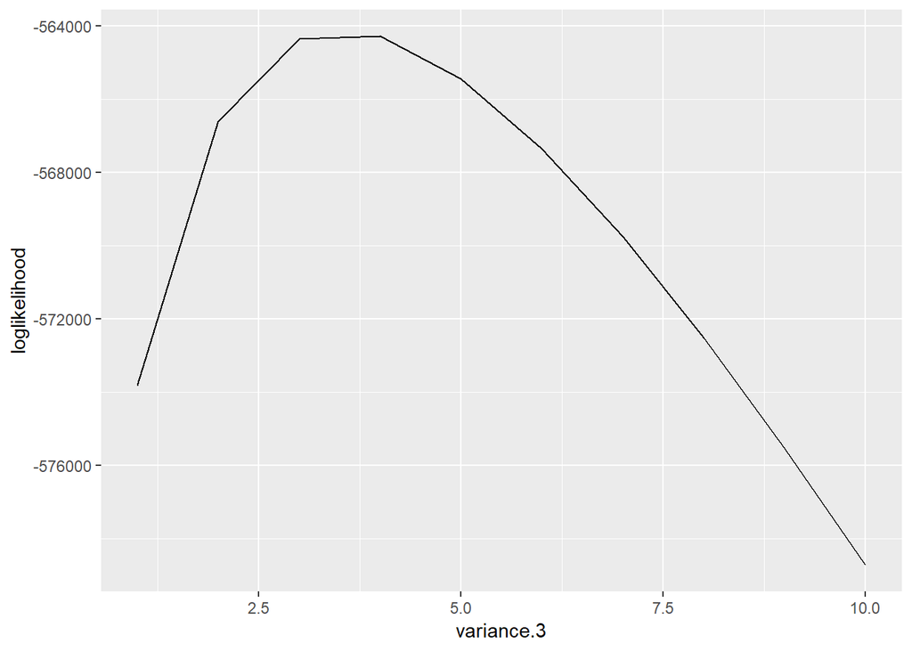

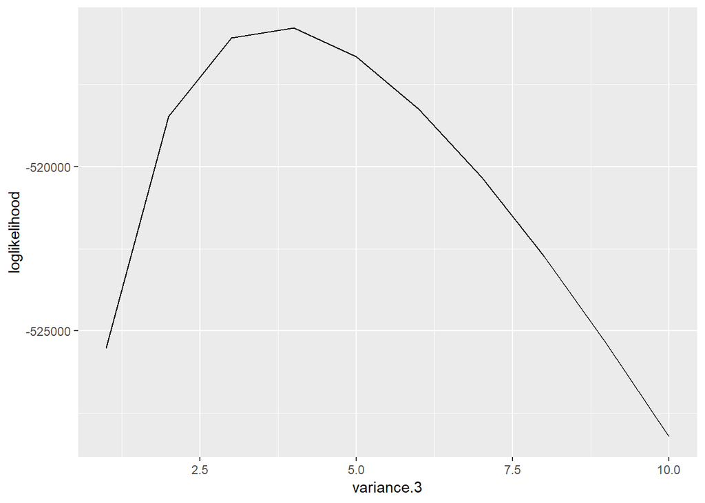

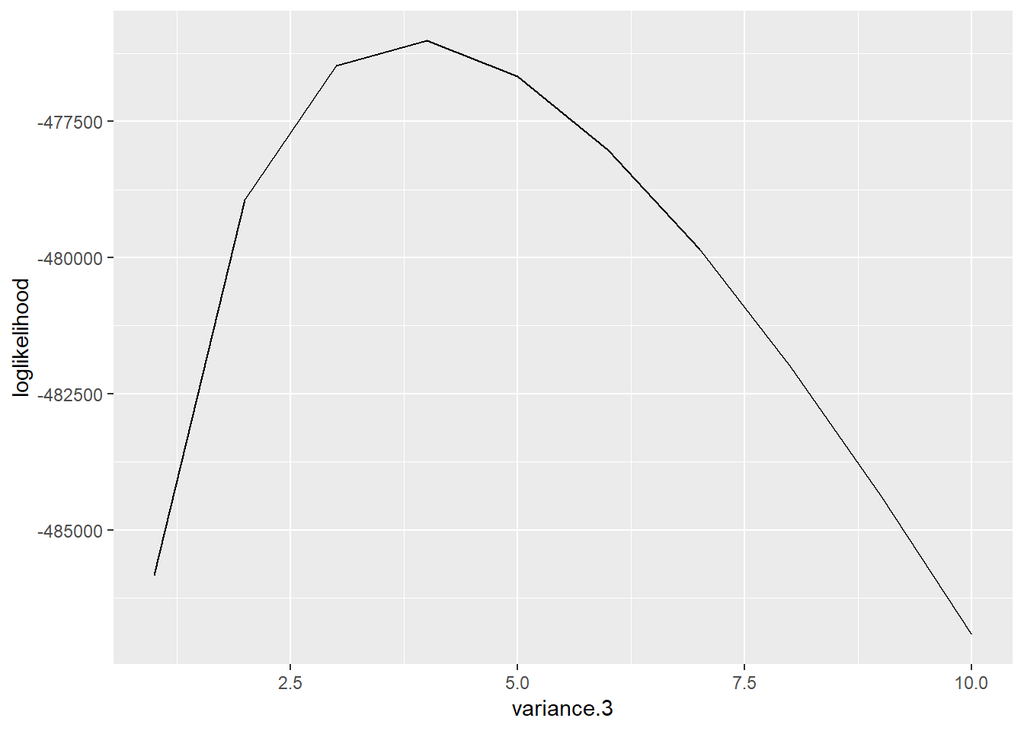

Plot them together: (Again, we fix the observation/irregular variance at 10)

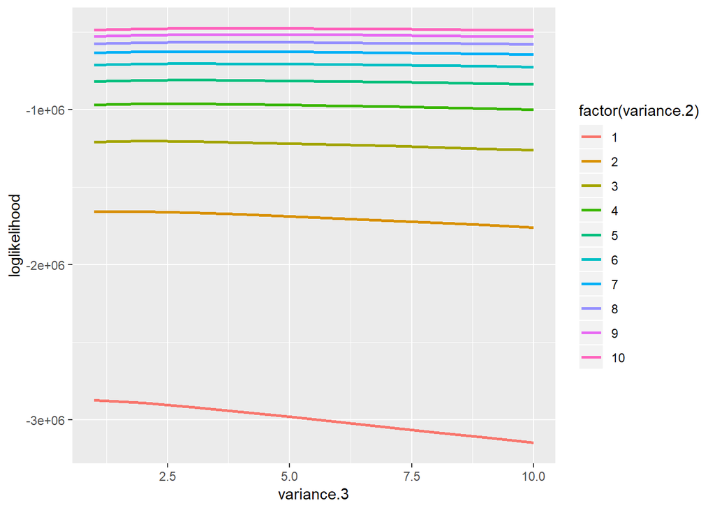

**Conclusion:** For unemployment dataset, the MLE of our parameters are c(10,10,4), which is different from c(10,7,4).

# MAP Estimate

As we know, $Posteriori \propto Prior * Likelihood$. If we take log, then $log(Post) \propto log(Prior) + log(likelihood) + constant$.

## Prior setting

Let’s use Gamma distributions at first:

```r
# gamma prior(ignore the coefficient)
prior_gamma <- function(alpha, beta, x)  x^(alpha-1)*exp(-x/beta)
```

Since we have three parameters, let’s suppose:

- the product of them is our Prior.

```r
Prior_gamma <- function(sigma, alpha, beta) {
  sigma[1]^(alpha[1]-1) * exp(-sigma[1]/beta[1]) *
  sigma[1]^(alpha[1]-1) * exp(-sigma[1]/beta[1]) *
  sigma[1]^(alpha[1]-1) * exp(-sigma[1]/beta[1])
}
```

```r
logPrior_gamma <- function(sigma, alpha, beta){
  (alpha[1]-1) * log(sigma[1]) - sigma[1]/beta[1] +
  (alpha[2]-1) * log(sigma[2]) - sigma[2]/beta[2] +
  (alpha[3]-1) * log(sigma[3]) - sigma[3]/beta[3]
}
```

## Posterior (prior is gamma)

```r
# define the log likelihood function

loglikelihood <- function(data, trend, season, sigma){

  n <- length(data)
  a <- 0
  for (i in 12:n)  a <- a + (sum(season[(i-11):i]))^2
  l <- -(n-11)/2 * log(sigma[1]) -
    (n-11)/2 * log(sigma[2]) - (n-11)/2 * log(sigma[3]) -
    sum((data[-c(1:11)]-trend[-c(1:11)]-season[-c(1:10,n)])^2)/(2*sigma[1]) -
    sum((trend[-c(1:11)]-trend[-c(1:10,n)])^2)/(2*sigma[2]) -
    a / (2*sigma[3])
  return(l)

}
```

```r
logposterior <- function(data, trend, season, sigma, alpha, beta){
  loglikelihood(data,trend,season,sigma) + logPrior_gamma(sigma, alpha, beta)
}
```

```r
logposterior_matrix <- function(data, alpha, beta){
  LP <- c()
  index <- c()
   for (i in 1:10) {
     for (j in 1:10) {
       for (k in 1:10) {

         ssmm <- SSModel(data ~ SSMtrend(1, Q=list(j)) +
                   SSMseasonal(12, sea.type = 'dummy', Q = k),
                 H = i)
         ssm <- KFS(ssmm)

         ssm_trend <- coef(ssm, states = 'trend')
         ssm_seasonal <- -rowSums(coef(ssm, states='seasonal'))
  #      ssm_seasadj <- data[-1] - ssm_seasonal[-length(data)] # length is shorter
         sigma <- c(i, j, k)

         lp <- logposterior(data, ssm_trend, ssm_seasonal, sigma, alpha, beta)
         LP <- c(LP, lp)
         index <- rbind(index, sigma)
         }
      }
   }
  df <- data.frame(variance=index, logposterior=LP)
  return(df)
}
```

```r
unemp_logposteriormatrix <- logposterior_matrix(unemp,alpha=c(10,5,0.5), beta=c(1,1,2))
unemp_logposteriormatrix[which.max(unemp_logposteriormatrix$logposterior),]
```

```
##           variance.1 variance.2 variance.3 logposterior
## sigma.993         10         10          4    -476010.1
```

Let’s see:

```r
unemp_LP_gammamatrix <- c()
for (i in 1:5) {
  for (j in 1:5) {
    for (k in 1:5) {
      alpha <- c(2^i,2^j,2^k)
      beta <- c(10,5,1)/alpha

      unemp_logposteriormatrix <- logposterior_matrix(unemp,alpha, beta)

      unemp_LP_gamma <-
        c(unemp_logposteriormatrix[which.max(unemp_logposteriormatrix$logposterior),], alpha, beta)
      unemp_LP_gammamatrix <- rbind(unemp_LP_gammamatrix, unemp_LP_gamma)
    }
  }
}
```

```r
class(unemp_LP_gammamatrix)
```

```
## [1] "matrix"
```

```r
head(unemp_LP_gammamatrix)
```

```
##                variance.1 variance.2 variance.3 logposterior
## unemp_LP_gamma 10         10         4          -476025.4    2 2 2  5 2.5
## unemp_LP_gamma 10         10         4          -476030.6    2 2 4  5 2.5
## unemp_LP_gamma 10         10         4          -476041      2 2 8  5 2.5
## unemp_LP_gamma 10         10         4          -476061.9    2 2 16 5 2.5
## unemp_LP_gamma 10         10         4          -476103.8    2 2 32 5 2.5
## unemp_LP_gamma 10         10         4          -476024.7    2 4 2  5 1.25
##
## unemp_LP_gamma 0.5
## unemp_LP_gamma 0.25
## unemp_LP_gamma 0.125
## unemp_LP_gamma 0.0625
## unemp_LP_gamma 0.03125
## unemp_LP_gamma 0.5
```

```r
write.csv(unemp_LP_gammamatrix, 'C:\\Users\\GuoLY\\Desktop\\markdown\\MLE & MAP\\unemp_LP_gammamatrix.csv')
```